# Trabalho Final

Autor

Mikael Marin Coletto

Data de Publicação

4 de agosto de 2024

# Introdução

Após a implementação do programa bolsa família em 2003, houve uma melhora significativa na qualidade de vida de muitas famílias brasileiras menos favorecidas, o impacto deste programa na saúde já é muito estudado e reconhecido cientificamente, portanto o primeiro objetivo deste estudo será avaliar a melhora na saúde dos recém nascidos, utilizando o peso ao nascer, um indicador de saúde do recém nascido, obtido do Sistema de Informações dos Nascidos Vivos. Além disso, tem estado em voga a discussão sobre a desigualdade racial no Brasil, e como isso impacta em diversos aspectos da vida dos brasileiros, inclusive na saúde, portanto diversos estudos sobre como o impacto da raça/cor influência na saúde do indivíduo tem sido conduzidos. Neste trabalho avaliaremos como a raça/cor da mãe pode influenciar em questões de saúde para o nascido vivo, utilizando novamente a variável de peso ao nascer obtida do SINASC.

# Objetivo

Este relatório tem o objetivo de construir análises sobre: I - O impacto do programa bolsa família na melhora da qualidade de vida dos recém nascidos. E para isto será avaliado a diferença entre o peso dos recém nascidos em 2003 e 2019. II - A relação entre a raça/cor da mãe e a saúde do nascido vivo. III - Estimação de intervalos de confiança para a média do peso dos recém nascidos. IV - Estimação pontual

Os dados utilizados serão do Sistema de Informação dos Nascidos Vivos (SINASC).

# Metodologia

Como possuímos os dados da população completa de nascidos vivos no Brasil, primeiramente faremos uma redução da base de dados, para que possamos realizar as análises em cima de dados amostrais, simulando um estudo onde não possuímos o conjunto populacional. Para determinar o tamanho da amostra, utilizaremos os conceitos estudados na disciplina de Inferência Estatística.

Após cálculo do tamanho da amostra, faremos uma amostragem para cada um dos problemas utilizados, e então realizaremos os testes de normalidade dos dados, para então começarmos as análises.

As análises consistirão em duas partes:

I - Calcular um intervalo de confiança para a média do peso dos recém nascidos com base na amostra de 2019, e então fazer uma estimação pontual para o peso.

II - Realizar dois testes de comparação de média usando teste de hipótese, o primeiro (a) Verificar se houve um aumento do peso médio dos recém nascidos entre 2003 e 2019. E o segundo (b) Verificar se existe uma diferença entre a média de peso dos recém nascidos de mães negras e brancas.

# Referêncial teórico

Para este trabalho, utilizaremos alguns conceitos estudados na disciplina de Inferência Estatística, como o cálculo do tamanho da amostra, e a construção de intervalos de confiança. Além disso, utilizaremos conceitos de testes de hipótese, com o teste t-student para comparação de médias em duas amostras.

Inicialmente, como temos os dados da população, faremos um cálculo de quantos indivíduos precisaríamos caso quiséssemos fazer algum tipo de estudo com esta população. O cálculo do tamanho de amostra, como nossa população é maior que 10000, será feito através da fórmula:

$$n = \left(\frac{z_{\alpha/2} * \sigma}{e }\right)^2$$

Então faremos os testes de normalidade dos dados, para garantir que possamos seguir com as análises e utilizar os testes de hipótese, em seguida faremos uma análise exploratória, para entendermos melhor a distribuição dos dados.

Além disso, por possuírmos uma amostra consideravelmente grande, entre 1.9 milhões e 17 milhões, dependendo dos dados que estão sendo utilizados, mesmo não passando nos testes de normalidade, utilizaremos o Teorema Central do Limite, que nos garante que a distribuição amostral da média é aproximadamente normal, mesmo que a distribuição da população não seja.

E por fim, testaremos duas hipóteses, para os dois problemas tratados, definindo a hipótese nula e alternativa, definindo o nosso nível de confiança e usar o teste-t para avaliar se aceitamos ou rejeitamos a hipótese nula.

# Começando a análise

## Lendo os dados do SINASC de 2010 à 2019

**Código**

```r
## Lendo dados
df_sinasc_2010_2019 <- data.table::fread("dados/sinasc.csv") |>
  dplyr::mutate(ano = as.integer(substr(DTNASC, 5, 8))) |>
  dplyr::select(-DTNASC)

df_sinasc_2003 <- data.table::fread("dados/sinasc_2003.csv") |>
  dplyr::mutate(ano = as.integer(substr(DTNASC, 5, 8))) |>
  dplyr::select(-DTNASC)
```

## Tratamento de dados

**Código**

```r
## Tratamento de dados
df_sinasc_2003 <- df_sinasc_2003 |>
  dplyr::filter(ano == 2003, PESO >= 1000 & PESO <= 6000)

df_sinasc_2010_2019 <- df_sinasc_2010_2019 |>
  dplyr::filter(ano >= 2010 & ano <= 2019,
                PESO >= 1000 & PESO <= 6000,
                !is.na(RACACORMAE))

df_sinasc_2019 <- df_sinasc_2010_2019 |>
  dplyr::filter(ano == 2019)
```

## Calculando tamanho da amostra

Para o cálculo do tamanho da amostra, utilizaremos os valores de **margem de erro** como **100g** e o **nível de confiança de 5%**, a fórmula:

**Código**

```r
## Calculando tamanho da amostra (para população de 2003)
nivel_conf <- 0.95
marg_erro <- 100
n_2003 = ceiling((qnorm(nivel_conf)*sd(df_sinasc_2003$PESO)/marg_erro)^2)

## Calculando tamanho da amostra para 2019
n_2019 = ceiling((qnorm(nivel_conf)*sd(df_sinasc_2019$PESO)/marg_erro)^2)

n_2010_2019 = ceiling((qnorm(nivel_conf)*sd(df_sinasc_2010_2019$PESO)/marg_erro)^2)
```

Neste caso, se quiséssemos trabalhar com amostras da nossa população, nosso estudo poderia contar com 78 à 83 indivíduos, para que pudéssemos realizar testes estatísticos válidos, além, claro, de que os demais pressupostos fossem atendidos.

## Retirando uma amostra da aleatória

Então, mesmo que a nossa amostra precise de um tamanho muito menor, como temos uma base relativamente grande, iremos tirar 10000 observações para cada base de dados.

**Código**

```r
## Amostragem
set.seed(42)
df_teste_2003 <- df_sinasc_2003 |>
  dplyr::sample_n(10000)

df_teste_2019 <- df_sinasc_2019 |>
  dplyr::sample_n(10000)

df_teste_2010_2019 <- df_sinasc_2010_2019 |>
  dplyr::sample_n(10000)
```

## Testando normalidade dos dados para variáveis utilizadas

### Peso

#### 2003

**Código**

```r
## Não usaremos Shapiro-Wilk por possuírmos mais que 5 mil observações na nossa base de dados
# shapiro.test(df_teste_2003$PESO)
nortest::ad.test(df_teste_2003$PESO)
```

```
    Anderson-Darling normality test

data:  df_teste_2003$PESO
A = 28.045, p-value < 0.00000000000000022
```

**Código**

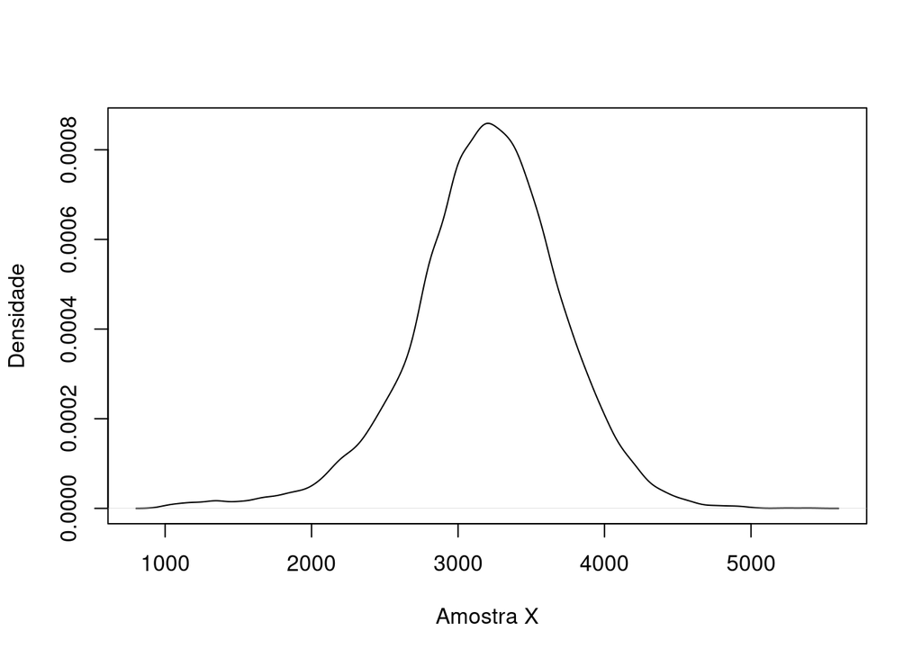

```r
plot(density(df_teste_2003$PESO), ylab='Densidade', xlab='Amostra X', main='')
```

#### 2019

**Código**

```r
## 2019
# shapiro.test(df_teste_2019$PESO)
nortest::ad.test(df_teste_2019$PESO)
```

```
    Anderson-Darling normality test

data:  df_teste_2019$PESO
A = 32.779, p-value < 0.00000000000000022
```

**Código**

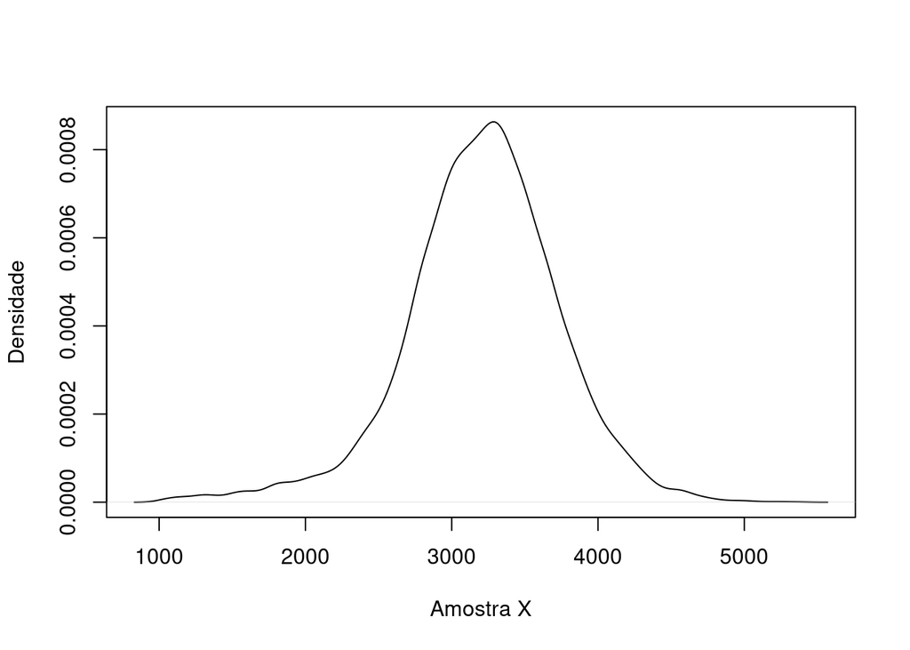

```r
plot(density(df_teste_2019$PESO), ylab='Densidade', xlab='Amostra X', main='')
```

#### 2010-2019

**Código**

```r
# shapiro.test(df_teste_2010_2019$PESO)
nortest::ad.test(df_teste_2010_2019$PESO)
```

```
    Anderson-Darling normality test

data:  df_teste_2010_2019$PESO
A = 37.791, p-value < 0.00000000000000022
```

**Código**

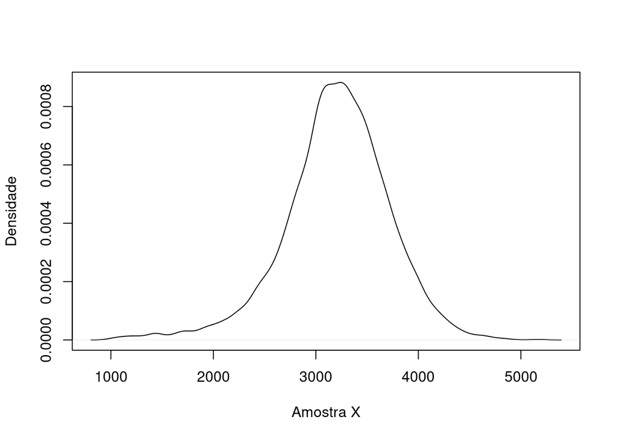

```r
plot(density(df_teste_2010_2019$PESO), ylab='Densidade', xlab='Amostra X', main='')
```

Nos testes de normalidade, todos os valores de p-valor foram todos menores que 0.05, portanto teremos que rejeitar a hipótese nula de que os dados são normais. Porém, para prosseguir com os testes de hipótese, utilizaremos o Teorema Central do Limite, que nos garante que a distribuição amostral da média é aproximadamente normal, contanto que usemos um tamanho amostral grande (n > 30), mesmo que a distribuição da população não seja.

As análises gráficas também corroboram com o Teorema, apresentando uma distribuição que se aproxima da normal.

## Análise exploratória das variáveis

### Tabela geral

**Código**

```r
## 2003
gtsummary::tbl_summary(df_teste_2003)
```

| **Characteristic** | **N = 10,000**<sup>1</sup> |
| --- | --- |
| PESO | 3,200 (2,900, 3,520) |
| PARTO |  |
| 1 | 5,908 (59%) |
| 2 | 4,073 (41%) |
| 9 | 14 (0.1%) |
| Unknown | 5 |
| ESCMAE |  |
| 0 | 41 (0.4%) |
| 1 | 347 (3.5%) |
| 2 | 1,262 (13%) |
| 3 | 3,571 (36%) |
| 4 | 3,272 (33%) |
| 5 | 1,225 (12%) |
| 9 | 168 (1.7%) |
| Unknown | 114 |
| IDADEMAE | 24 (20, 29) |
| Unknown | 17 |
| ano |  |
| 2003 | 10,000 (100%) |

<sup>1</sup> Median (Q1, Q3); n (%)

**Código**

```r
## 2019
gtsummary::tbl_summary(df_teste_2019)
```

| **Characteristic** | **N = 10,000**<sup>1</sup> |
| --- | --- |
| PESO | 3,228 (2,910, 3,535) |
| RACACORMAE |  |
| 1 | 3,490 (35%) |
| 2 | 652 (6.5%) |
| 3 | 40 (0.4%) |
| 4 | 5,726 (57%) |
| 5 | 92 (0.9%) |
| PARTO |  |
| 1 | 4,385 (44%) |
| 2 | 5,608 (56%) |
| Unknown | 7 |
| ESCMAEAGR1 | 6 (5, 8) |
| Unknown | 41 |
| ESCMAE |  |
| 1 | 28 (0.3%) |
| 2 | 152 (1.5%) |
| 3 | 1,402 (14%) |
| 4 | 6,231 (63%) |
| 5 | 2,105 (21%) |
| 9 | 42 (0.4%) |
| Unknown | 40 |
| IDADEMAE | 27 (22, 32) |
| ano |  |
| 2019 | 10,000 (100%) |

<sup>1</sup> Median (Q1, Q3); n (%)

**Código**

```r
## 2010-2019
gtsummary::tbl_summary(df_teste_2010_2019)
```

| **Characteristic** | **N = 10,000**<sup>1</sup> |
| --- | --- |
| PESO | 3,225 (2,925, 3,530) |
| RACACORMAE |  |
| 1 | 3,524 (35%) |
| 2 | 588 (5.9%) |
| 3 | 33 (0.3%) |
| 4 | 5,742 (57%) |
| 5 | 99 (1.0%) |
| 9 | 14 (0.1%) |
| PARTO |  |
| 1 | 4,338 (43%) |
| 2 | 5,653 (57%) |
| Unknown | 9 |
| ESCMAEAGR1 | 6 (4, 8) |
| Unknown | 1,893 |
| ESCMAE |  |
| 1 | 57 (0.6%) |
| 2 | 314 (3.2%) |
| 3 | 1,855 (19%) |
| 4 | 5,890 (59%) |
| 5 | 1,736 (18%) |
| 9 | 66 (0.7%) |
| Unknown | 82 |
| IDADEMAE | 26 (21, 31) |
| ano | 2,015 (2,013, 2,017) |

<sup>1</sup> Median (Q1, Q3); n (%)